# PS15 Section 1

### REMINDERS

1. KNIT AS YOU GO!
2. ALWAYS SET YOUR WORKING DIRECTORY FIRST
3. MAKE SURE YOU KNOW WHAT YOUR VARIABLES ARE (X and Y)
4. NEVER CODE IN THE CONSOLE
5. KEEP ANSWERS/QUESTIONS SEPARATE FOR EASY READING

### R IS A GIANT CALCULATOR

```r
1+1
```

```
## [1] 2
```

```r
75*69
```

```
## [1] 5175
```

### IMPORT DATA

First of all, set up your working directory!

```r
getwd()
```

```
## [1] "/home/jovyan/UCSB_PS15/Section 1"
```

```r
setwd("/home/jovyan/UCSB_PS15/Section 1/")
# We make comments in R by placing a hashtag in front of text.

getwd()
```

```
## [1] "/home/jovyan/UCSB_PS15/Section 1"
```

Now we want to load a dataset into R. Here’s how you do it. Make sure that when you do this, your data is in the same working directory that you set up before!

```r
schooldata <- read.csv("schooldata.csv", header = T)
```

### EXPLORE DATASET

First look at the first 6 lines of our dataset.

```r
head(schooldata)
```

```
##   school gender math_score language_score absences
## 1      1      M       56.4           44.1        4
## 2      1      M       36.3           48.2        4
## 3      1      F       31.9           42.7        2
## 4      1      F       28.9           42.2        3
## 5      1      F        6.3           28.6        3
## 6      1      F       62.6           48.5       13
```

```r
# What can you learn from the result?
```

Then let us look at the last 6 lines of our dataset.

```r
tail(schooldata)
```

```
##     school gender math_score language_score absences
## 311      2      F       49.1           71.9        1
## 312      2      M       35.9           49.0        1
## 313      2      F       65.8           67.2        3
## 314      2      F       55.2           54.1        0
## 315      2      F       78.8           68.9        0
## 316      2      F       64.9           71.9        2
```

Count the number of rows

```r
nrow(schooldata)
```

```
## [1] 316
```

Count the number of columns

```r
ncol(schooldata)
```

```
## [1] 5
```

### EXPLORE DATA PATTERN (FOR ONE VARIABLE)

1. The range of students’ language scores

```r
range(schooldata$language_score)
```

```
## [1]   0.2 100.0
```

2. The minimum and maximum of the language scores

```r
min(schooldata$language_score)
```

```
## [1] 0.2
```

```r
max(schooldata$language_score)
```

```
## [1] 100
```

3. Actually, we have an easier way to explore the pattern of the variable language score

```r
summary(schooldata)
```

```
##      school         gender            math_score    language_score
##  Min.   :1.000   Length:316         Min.   : 0.50   Min.   :  0.20
##  1st Qu.:1.000   Class :character   1st Qu.:37.95   1st Qu.: 40.60
##  Median :1.000   Mode  :character   Median :49.15   Median : 50.05
##  Mean   :1.497                      Mean   :48.75   Mean   : 50.13
##  3rd Qu.:2.000                      3rd Qu.:60.90   3rd Qu.: 60.75
##  Max.   :2.000                      Max.   :99.80   Max.   :100.00
##     absences
##  Min.   : 0.00
##  1st Qu.: 1.00
##  Median : 3.00
##  Mean   : 5.81
##  3rd Qu.: 8.00
##  Max.   :45.00
```

```r
summary(schooldata$language_score)
```

```
##    Min. 1st Qu.  Median    Mean 3rd Qu.    Max.
##    0.20   40.60   50.05   50.13   60.75  100.00
```

4. Let us visualize the distribution of the variable that we are interested in.

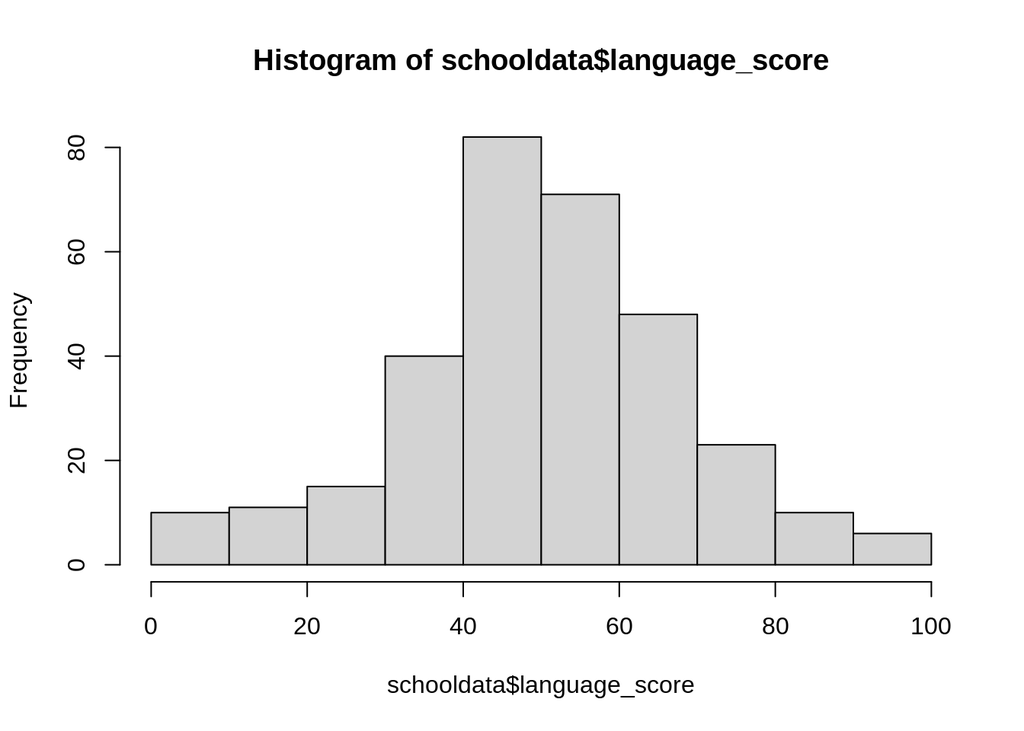

```r
hist(schooldata$language_score)
```

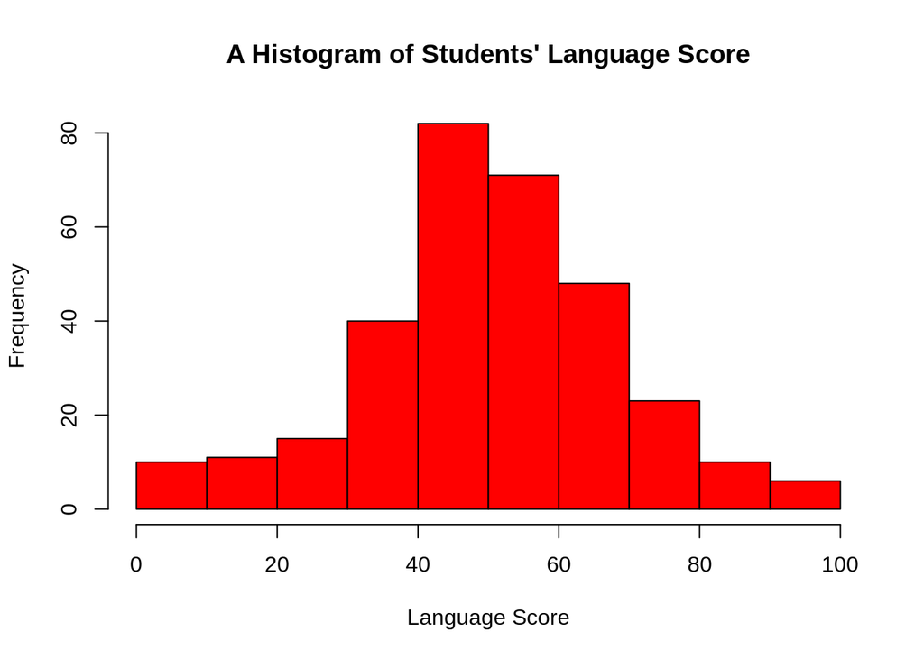

```r
# To make a more precise graph, we can add arguments to our code
hist(schooldata$language_score,
     xlab = "Language Score",
     main = "A Histogram of Students' Language Score",
     col = "red")
```

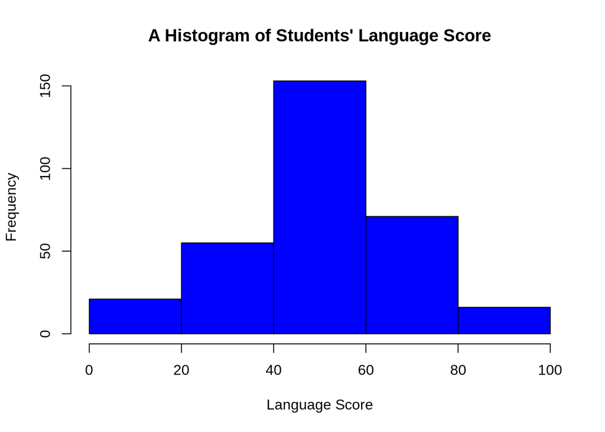

```r
hist(schooldata$language_score,
     xlab = "Language Score",
     main = "A Histogram of Students' Language Score",
     col = "blue", breaks = 5)
```

### EXPLORE THE RELATIONSHIP BETWEEN TWO VARIABLES

Let’s make a simple scatterplot with absences on the horizontal axis (x-axis), and math scores on the vertical axis (y-axis), with labels.

We now estimate a regression (looking at the relationship between variables). Let’s add a regression line based on the linear regression model, in order to look at the effect of the IV (Independent variable) on the DV (Dependent Variable).

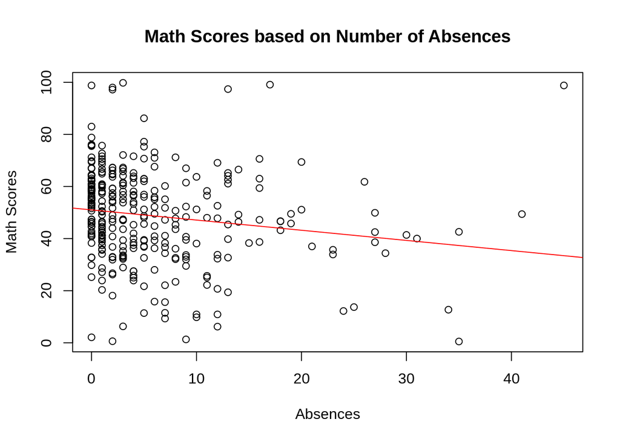

```r
model <- lm(schooldata$math_score ~ schooldata$absences,
            data = schooldata)
plot(schooldata$absences, schooldata$math_score,
     xlab = "Absences",
     ylab = "Math Scores",
     main = "Math Scores based on Number of Absences")
abline(model, col="red")
```

```r
# What type of relationship exists between math scores and attendance?

summary(model)
```

```
##
## Call:
## lm(formula = schooldata$math_score ~ schooldata$absences, data = schooldata)
##
## Residuals:
##    Min     1Q Median     3Q    Max
## -49.63 -10.59   1.47  11.23  65.36
##
## Coefficients:
##                     Estimate Std. Error t value Pr(>|t|)
## (Intercept)          51.0150     1.2673  40.255  < 2e-16 ***
## schooldata$absences  -0.3907     0.1343  -2.909  0.00388 **
## ---
## Signif. codes:  0 '***' 0.001 '**' 0.01 '*' 0.05 '.' 0.1 ' ' 1
##
## Residual standard error: 17.75 on 314 degrees of freedom
## Multiple R-squared:  0.02625,    Adjusted R-squared:  0.02315
## F-statistic: 8.464 on 1 and 314 DF,  p-value: 0.003881
```